# ANÁLISE DOS DADOS GLOBAIS DE COVID-19

Alex F. Viana

19 de junho, 2021

# 1 Fonte

O Dataset em questão trata-se de uma **série temporal de casos e óbitos globais**, provenientes dos dados da **Johns Hopkins University CSSE COVID-19** e também do **The New York Times**, publicados e atualizados diariamente no **data.world**, disponibilizado pelo endereço https://data.world/covid-19-data-resource-hub/covid-19-case-counts.

Para auxílio na elaboração de indicadores, foi utilizada uma planilha auxiliar elaborada a partir das informações do site **worldometers** https://www.worldometers.info/world-population/population-by-country/, e com o “de para” dos nomes dos países, permitindo a melhor integração entre ambas as fontes.

# 2 Bibliotecas

Carregamento das bibliotecas para manipulação dos dados:

```r
library(readr)
library(dplyr)
library(readxl)
library(Amelia)
library(zoo)
library(ggplot2)
library(knitr)
library(rmarkdown)
library(kableExtra)
```

# 3 Carregamento dos dados

Visualização da estrutura dos arquivos

## 3.1 “COVID-19 Activity.csv”

```
## Rows: 1,823,672
## Columns: 13
## $ PEOPLE_POSITIVE_CASES_COUNT     <dbl> 2830, 2203, 25, 1185, 0, 2497, 228, 28~
## $ COUNTY_NAME                     <chr> "Montgomery", "Montgomery", "Montgomer~
## $ PROVINCE_STATE_NAME             <chr> "Kentucky", "Kentucky", "Kentucky", "K~
## $ REPORT_DATE                     <date> 2021-06-08, 2021-02-16, 2020-06-02, 2~
## $ CONTINENT_NAME                  <chr> "America", "America", "America", "Amer~
## $ DATA_SOURCE_NAME                <chr> "New York Times", "New York Times", "N~
## $ PEOPLE_DEATH_NEW_COUNT          <dbl> 0, 0, 0, 0, 0, 0, 0, 0, 0, 0, 0, 0, 0,~
## $ COUNTY_FIPS_NUMBER              <chr> "21173", "21173", "21173", "21173", "2~
## $ COUNTRY_ALPHA_3_CODE            <chr> "USA", "USA", "USA", "USA", "USA", "US~
## $ COUNTRY_SHORT_NAME              <chr> "United States", "United States", "Uni~
## $ COUNTRY_ALPHA_2_CODE            <chr> "US", "US", "US", "US", "US", "US", "U~
## $ PEOPLE_POSITIVE_NEW_CASES_COUNT <dbl> 5, 23, 0, 3, 0, 2, 1, 1, 3, 1, 0, 6, 3~
## $ PEOPLE_DEATH_COUNT              <dbl> 30, 23, 0, 12, 0, 30, 3, 30, 0, 0, 0, ~
```

## 3.2 “World Data Base.xlsx”

```
## Rows: 235
## Columns: 17
## $ `0`                       <dbl> 1, 2, 3, 4, 5, 6, 7, 8, 9, 10, 11, 12, 13, 1~
## $ `Country (or dependency)` <chr> "China", "India", "United States", "Indonesi~
## $ `Country (Worldometers)`  <chr> "China", "India", "United States", "Indonesi~
## $ `País (pt)`               <chr> "China", "Índia", "Estados Unidos", "Indonés~
## $ `Population 2020`         <dbl> 1439323776, 1380004385, 331002651, 273523615~
## $ `Density (P/Km²)`         <dbl> 153, 464, 36, 151, 287, 25, 226, 1265, 9, 66~
## $ `Land Area (Km²)`         <dbl> 9388211, 2973190, 9147420, 1811570, 770880, ~
## $ Migrants                  <dbl> -348399, -532687, 954806, -98955, -233379, 2~
## $ `Fert. Rate`              <dbl> 2, 2, 2, 2, 4, 2, 5, 2, 2, 2, 1, 4, 3, 3, 2,~
## $ `Med. Age`                <dbl> 38, 28, 38, 30, 23, 33, 18, 28, 40, 29, 48, ~
## $ `Urban Pop %`             <dbl> 0.61, 0.35, 0.83, 0.56, 0.35, 0.88, 0.52, 0.~
## $ `World Share`             <dbl> 0.1847, 0.1770, 0.0425, 0.0351, 0.0283, 0.02~
## $ Region                    <chr> "Ásia", "Ásia", "América do Norte", "Ásia", ~
## $ Lat                       <chr> "31.692699999999999", "20.593684", "37.46231~
## $ Long                      <chr> "88.092399999999998", "78.962879999999998", ~
## $ `Lat. Group`              <chr> "Norte 30º a 45º", "Norte 15º a 30º", "Norte~
## $ `1º Covid-19 Death`       <dttm> 2020-01-11, 2020-03-11, 2020-02-29, 2020-03~
```

# 4 Manipulação dos dados

## 4.1 Adequação dos dataframes

Retrabalhando o dataframe “df_original” renomeando as colunas e deixando-o mais enxuto.

```r
df_original <- df_original %>%
  select(country = COUNTRY_SHORT_NAME,
         data = REPORT_DATE,
         novos_obitos = PEOPLE_DEATH_NEW_COUNT,
         total_obitos = PEOPLE_DEATH_COUNT,
         novos_casos = PEOPLE_POSITIVE_NEW_CASES_COUNT,
         total_casos = PEOPLE_POSITIVE_CASES_COUNT
         )

kable(head(df_original,10)) %>%
  kable_styling(full_width = F, bootstrap_options = c("striped", "hover", "condensed"))
```

| country | data | novos_obitos | total_obitos | novos_casos | total_casos |
| --- | --- | --- | --- | --- | --- |
| United States | 2021-06-08 | 0 | 30 | 5 | 2830 |
| United States | 2021-02-16 | 0 | 23 | 23 | 2203 |
| United States | 2020-06-02 | 0 | 0 | 0 | 25 |
| United States | 2020-12-13 | 0 | 12 | 3 | 1185 |
| United States | 2020-03-05 | 0 | 0 | 0 | 0 |
| United States | 2021-04-14 | 0 | 30 | 2 | 2497 |
| United States | 2020-09-17 | 0 | 3 | 1 | 228 |
| United States | 2021-06-16 | 0 | 30 | 1 | 2847 |
| United States | 2020-07-19 | 0 | 0 | 3 | 89 |
| United States | 2020-05-30 | 0 | 0 | 1 | 24 |

Padronizando o nome das colunas do dataframe “df_info” e eliminando as colunas excedentes

```r
df_info <- df_info %>%
  select(country = `Country (or dependency)`,
         pais = `País (pt)`,
         habitantes = `Population 2020`,
         continente = Region,
         )

kable(head(df_info,10))  %>%
  kable_styling(full_width = F, bootstrap_options = c("striped", "hover", "condensed"))
```

| country | pais | habitantes | continente |
| --- | --- | --- | --- |
| China | China | 1439323776 | Ásia |
| India | Índia | 1380004385 | Ásia |
| United States | Estados Unidos | 331002651 | América do Norte |
| Indonesia | Indonésia | 273523615 | Ásia |
| Pakistan | Paquistão | 220892340 | Ásia |
| Brazil | Brasil | 212559417 | América do Sul |
| Nigeria | Nigéria | 206139589 | África |
| Bangladesh | Bangladesh | 164689383 | Ásia |
| Russia | Rússia | 145934462 | Europa |
| Mexico | México | 128932753 | América do Norte |

## 4.2 Consolidação dos dados

Criação do dataframe “df_master” a partir da união dos dois dataframes e com a inclusão de novos indicadores

```r
df_master <- left_join(df_original, df_info, by = "country") %>%
  group_by(pais, continente, data) %>%
  summarise(country = first(country),
            novos_obitos = sum(novos_obitos),
            total_obitos = sum(total_obitos),
            novos_casos = sum(novos_casos),
            total_casos = sum(total_casos),
            habitantes = mean(habitantes)
            ) %>%
  mutate(novos_obitos_MH = round((1000000 * novos_obitos / habitantes),2),
         total_obitos_MH = round((1000000 * total_obitos / habitantes),2),
         novos_casos_MH = round((1000000 * novos_casos / habitantes),2),
         total_casos_MH = round((1000000 * total_casos / habitantes),2),
         letalidade = round(if_else(total_casos == 0,
                                    0,
                                    total_obitos / total_casos
                           ) * 100 , 2)
         ) %>%
  arrange(pais,desc(data))

glimpse(df_master)
```

```
## Rows: 112,566
## Columns: 14
## Groups: pais, continente [219]
## $ pais            <chr> "Afeganistão", "Afeganistão", "Afeganistão", "Afeganis~
## $ continente      <chr> "Ásia", "Ásia", "Ásia", "Ásia", "Ásia", "Ásia", "Ásia"~
## $ data            <date> 2021-06-17, 2021-06-16, 2021-06-15, 2021-06-14, 2021-~
## $ country         <chr> "Afghanistan", "Afghanistan", "Afghanistan", "Afghanis~
## $ novos_obitos    <dbl> 159, 0, 71, 85, 78, 37, 56, 51, 54, 64, 42, 41, 36, 34~
## $ total_obitos    <dbl> 3842, 3683, 3683, 3612, 3527, 3449, 3412, 3356, 3305, ~
## $ novos_casos     <dbl> 3243, 16, 1814, 1597, 1121, 1024, 1824, 1842, 1724, 14~
## $ total_casos     <dbl> 96531, 93288, 93272, 91458, 89861, 88740, 87716, 85892~
## $ habitantes      <dbl> 38928346, 38928346, 38928346, 38928346, 38928346, 3892~
## $ novos_obitos_MH <dbl> 4.08, 0.00, 1.82, 2.18, 2.00, 0.95, 1.44, 1.31, 1.39, ~
## $ total_obitos_MH <dbl> 98.69, 94.61, 94.61, 92.79, 90.60, 88.60, 87.65, 86.21~
## $ novos_casos_MH  <dbl> 83.31, 0.41, 46.60, 41.02, 28.80, 26.30, 46.86, 47.32,~
## $ total_casos_MH  <dbl> 2479.71, 2396.40, 2395.99, 2349.39, 2308.37, 2279.57, ~
## $ letalidade      <dbl> 3.98, 3.95, 3.95, 3.95, 3.92, 3.89, 3.89, 3.91, 3.93, ~
```

## 4.3 Verificação de inconsistências

Verificação de inconsistências após a união dos dataframes

```r
sum(is.na(df_master))
```

```
## [1] 3598
```

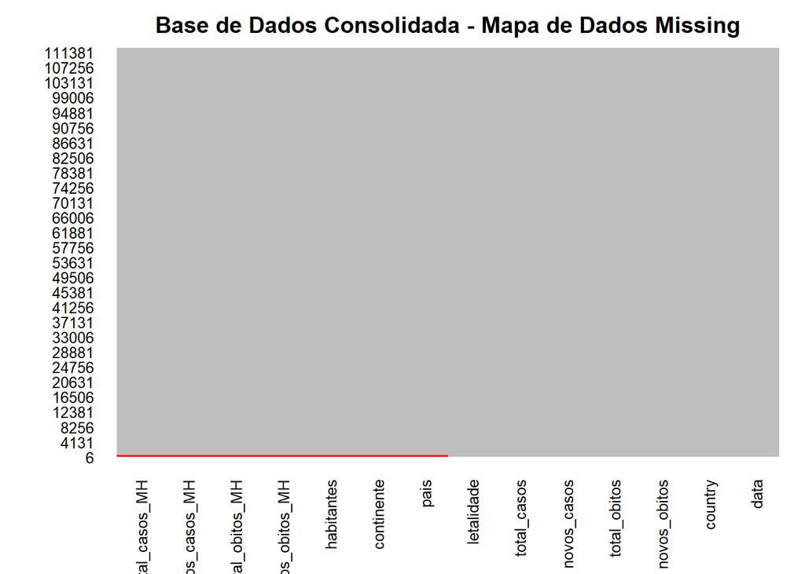

```r
missmap(df_master,
        main = "Base de Dados Consolidada - Mapa de Dados Missing",
        col = c("red", "gray"),
        legend = FALSE)
```

Identificação dos países que ficaram com informações em branco no data frame

```r
paises_na <- df_master %>%
  select(country, pais) %>%
  group_by(country) %>%
  summarise(pais = first(pais))  %>%
  filter(is.na(pais))

kable(paises_na) %>%
  kable_styling(full_width = F, bootstrap_options = c("striped", "hover", "condensed"))
```

| country | pais |
| --- | --- |
| Bonaire, Sint Eustatius and Saba | NA |
| Burma | NA |
| Kosovo | NA |

Eliminação das divergências com a exclusão das linhas dos 3 paises cujas informações não foram encontradas.

```r
df_master <- df_master %>%
  filter(pais != "")

sum(is.na(df_master ))
```

```
## [1] 0
```

## 4.4 Inclusão das médias móveis

Inclusão dos indicadores de médias móveis para óbitos, óbitos por milhão, casos e casos por milhão

```r
df_master$obitos_MM7d <- round(
  rollmean(df_master$novos_obitos,7,na.pad = TRUE, align = "left") ,2)


df_master$obitos_MM7d_1MH <- round(
  rollmean(df_master$novos_obitos_MH,7,na.pad = TRUE, align = "left") ,2)

df_master$casos_MM7d <- round(
  rollmean(df_master$novos_casos,7,na.pad = TRUE, align = "left") ,2)


df_master$casos_MM7d_1MH <- round(
  rollmean(df_master$novos_casos_MH,7,na.pad = TRUE, align = "left") ,2)

glimpse(df_master)
```

```
## Rows: 112,052
## Columns: 18
## Groups: pais, continente [218]
## $ pais            <chr> "Afeganistão", "Afeganistão", "Afeganistão", "Afeganis~
## $ continente      <chr> "Ásia", "Ásia", "Ásia", "Ásia", "Ásia", "Ásia", "Ásia"~
## $ data            <date> 2021-06-17, 2021-06-16, 2021-06-15, 2021-06-14, 2021-~
## $ country         <chr> "Afghanistan", "Afghanistan", "Afghanistan", "Afghanis~
## $ novos_obitos    <dbl> 159, 0, 71, 85, 78, 37, 56, 51, 54, 64, 42, 41, 36, 34~
## $ total_obitos    <dbl> 3842, 3683, 3683, 3612, 3527, 3449, 3412, 3356, 3305, ~
## $ novos_casos     <dbl> 3243, 16, 1814, 1597, 1121, 1024, 1824, 1842, 1724, 14~
## $ total_casos     <dbl> 96531, 93288, 93272, 91458, 89861, 88740, 87716, 85892~
## $ habitantes      <dbl> 38928346, 38928346, 38928346, 38928346, 38928346, 3892~
## $ novos_obitos_MH <dbl> 4.08, 0.00, 1.82, 2.18, 2.00, 0.95, 1.44, 1.31, 1.39, ~
## $ total_obitos_MH <dbl> 98.69, 94.61, 94.61, 92.79, 90.60, 88.60, 87.65, 86.21~
## $ novos_casos_MH  <dbl> 83.31, 0.41, 46.60, 41.02, 28.80, 26.30, 46.86, 47.32,~
## $ total_casos_MH  <dbl> 2479.71, 2396.40, 2395.99, 2349.39, 2308.37, 2279.57, ~
## $ letalidade      <dbl> 3.98, 3.95, 3.95, 3.95, 3.92, 3.89, 3.89, 3.91, 3.93, ~
## $ obitos_MM7d     <dbl> 69.43, 54.00, 61.71, 60.71, 54.57, 49.29, 49.14, 46.00~
## $ obitos_MM7d_1MH <dbl> 1.78, 1.39, 1.58, 1.56, 1.40, 1.27, 1.26, 1.18, 1.09, ~
## $ casos_MM7d      <dbl> 1519.86, 1319.71, 1563.71, 1516.71, 1519.57, 1539.57, ~
## $ casos_MM7d_1MH  <dbl> 39.04, 33.90, 40.17, 38.96, 39.04, 39.55, 40.69, 39.53~
```

# 5 Visualização dos dados

## 5.1 Tabelas de síntese

Função para apresentação dos dados em formato de tabela

```r
tabela_sint <- function(dfx) {
  kable(
    head(
      dfx %>%
        group_by(pais) %>%
        summarise(obitos = sum(novos_obitos),
                  obitos_1M_hab = sum(novos_obitos_MH),
                  casos = sum(novos_casos),
                  casos_1M_hab = max(total_casos_MH),
                  obitos_MM7d_1MH = first(obitos_MM7d_1MH),
                  casos_MM7d_1MH = first(casos_MM7d_1MH),
                  habitantes = mean(habitantes)
                  ) %>%
        arrange(desc(obitos_MM7d_1MH))
    ,15)
  ) %>%
    kable_styling(full_width = F, bootstrap_options = c("striped", "hover"))
}
```

Top 15 dos paises com maior média de óbitos nos últimos 7 dias - Informações globais e por continente.

### 5.1.1 Global

```r
tabela_sint(df_master)
```

| pais | obitos | obitos_1M_hab | casos | casos_1M_hab | obitos_MM7d_1MH | casos_MM7d_1MH | habitantes |
| --- | --- | --- | --- | --- | --- | --- | --- |
| Paraguai | 11294 | 1582.84 | 401243 | 56255.29 | 17.66 | 325.55 | 7132538 |
| Seychelles | 55 | 559.29 | 14123 | 143603.77 | 13.07 | 2406.93 | 98347 |
| Suriname | 436 | 742.78 | 19361 | 33003.65 | 12.66 | 441.99 | 586632 |
| Argentina | 87789 | 1942.29 | 4222400 | 93424.66 | 12.16 | 493.87 | 45195774 |
| Uruguai | 5152 | 1483.36 | 348662 | 100371.07 | 11.93 | 766.36 | 3473730 |
| Colômbia | 98156 | 1929.00 | 3859824 | 75857.01 | 11.54 | 546.60 | 50882891 |
| Brasil | 496004 | 2333.44 | 17702630 | 83283.21 | 9.40 | 330.44 | 212559417 |
| Peru | 189757 | 5755.10 | 2019716 | 61255.76 | 8.27 | 105.97 | 32971854 |
| Namíbia | 1107 | 435.47 | 70112 | 27593.32 | 7.82 | 491.28 | 2540905 |
| Bolívia | 15924 | 1364.28 | 417195 | 35740.11 | 7.38 | 209.86 | 11673021 |
| Trinidad e Tobago | 699 | 499.17 | 29956 | 21404.97 | 7.04 | 219.47 | 1399488 |
| Bahrain | 1271 | 747.41 | 261501 | 153681.74 | 6.97 | 465.70 | 1701575 |
| Bósnia e Herzegovina | 9626 | 2933.69 | 204791 | 62420.69 | 6.66 | 9.75 | 3280819 |
| Chile | 31140 | 1628.86 | 1498231 | 78374.93 | 5.99 | 334.45 | 19116201 |
| Tunísia | 13792 | 1166.94 | 376691 | 31872.67 | 5.89 | 169.62 | 11818619 |

### 5.1.2 Ásia

```r
tabela_sint(df_master[which(df_master$continente == "Ásia"),])
```

| pais | obitos | obitos_1M_hab | casos | casos_1M_hab | obitos_MM7d_1MH | casos_MM7d_1MH | habitantes |
| --- | --- | --- | --- | --- | --- | --- | --- |
| Bahrain | 1271 | 747.41 | 261501 | 153681.74 | 6.97 | 465.70 | 1701575 |
| Omã | 2626 | 514.28 | 242723 | 47530.99 | 4.45 | 349.80 | 5106626 |
| Georgia | 5114 | 1281.98 | 356920 | 89472.31 | 4.23 | 177.84 | 3989167 |
| Sri Lanka | 2425 | 113.26 | 233064 | 10884.10 | 3.44 | 112.95 | 21413249 |
| Mongólia | 411 | 125.53 | 88516 | 27000.66 | 3.36 | 785.86 | 3278290 |
| Maldivas | 201 | 371.85 | 71356 | 132007.76 | 2.64 | 481.00 | 540544 |
| Malásia | 4202 | 129.55 | 678764 | 20971.51 | 2.29 | 173.03 | 32365999 |
| Índia | 383490 | 277.94 | 29762793 | 21567.17 | 2.11 | 50.52 | 1380004385 |
| Afeganistão | 3842 | 98.88 | 96531 | 2479.71 | 1.78 | 39.04 | 38928346 |
| Nepal | 8597 | 294.80 | 615984 | 21141.09 | 1.76 | 70.10 | 29136808 |
| Irã | 82619 | 983.58 | 3070426 | 36555.76 | 1.61 | 114.49 | 83992949 |
| Filipinas | 23276 | 212.34 | 1339457 | 12223.43 | 1.26 | 59.67 | 109581078 |
| Kuweit | 1842 | 431.07 | 334216 | 78260.26 | 1.07 | 363.25 | 4270571 |
| Quirguistão | 1916 | 293.77 | 112777 | 17285.96 | 1.03 | 89.99 | 6524195 |
| Jordânia | 9635 | 944.40 | 745366 | 73052.65 | 0.91 | 44.63 | 10203134 |

### 5.1.3 Europa

```r
tabela_sint(df_master[which(df_master$continente == "Europa"),])
```

| pais | obitos | obitos_1M_hab | casos | casos_1M_hab | obitos_MM7d_1MH | casos_MM7d_1MH | habitantes |
| --- | --- | --- | --- | --- | --- | --- | --- |
| Bósnia e Herzegovina | 9626 | 2933.69 | 204791 | 62420.69 | 6.66 | 9.75 | 3280819 |
| Romênia | 32115 | 1669.40 | 1080070 | 56143.43 | 4.34 | 4.77 | 19237691 |
| Liechtenstein | 59 | 1547.45 | 3026 | 79364.25 | 3.75 | 11.24 | 38128 |
| Letônia | 2482 | 1315.54 | 136544 | 72391.13 | 2.95 | 72.71 | 1886198 |
| Rússia | 125853 | 862.40 | 5203117 | 35653.79 | 2.62 | 92.90 | 145934462 |
| Bulgária | 17980 | 2587.64 | 420859 | 60568.80 | 1.91 | 15.81 | 6948445 |
| Croácia | 8165 | 1988.77 | 358918 | 87428.66 | 1.91 | 23.42 | 4105267 |
| Montenegro | 1604 | 2553.81 | 100020 | 159250.78 | 1.82 | 29.57 | 628066 |
| Grécia | 12488 | 1198.24 | 417253 | 40031.74 | 1.62 | 55.96 | 10423054 |
| Lituânia | 4357 | 1600.54 | 278177 | 102184.96 | 1.57 | 50.11 | 2722289 |
| Ucrânia | 54041 | 1235.66 | 2288155 | 52320.10 | 1.42 | 28.09 | 43733762 |
| Eslovenia | 4409 | 2120.71 | 256784 | 123516.91 | 1.10 | 46.79 | 2078938 |
| Irlanda | 4979 | 1008.50 | 267949 | 54265.01 | 1.10 | 63.94 | 4937786 |
| Polônia | 74734 | 1974.64 | 2878276 | 76051.09 | 1.08 | 6.07 | 37846611 |
| Alemanha | 90277 | 1077.67 | 3727668 | 44491.44 | 1.00 | 15.43 | 83783942 |

### 5.1.4 América Central/Norte

```r
tabela_sint(df_master[which(df_master$continente == "América do Norte" |
                         df_master$continente == "América Central"),])
```

| pais | obitos | obitos_1M_hab | casos | casos_1M_hab | obitos_MM7d_1MH | casos_MM7d_1MH | habitantes |
| --- | --- | --- | --- | --- | --- | --- | --- |
| Trinidad e Tobago | 699 | 499.17 | 29956 | 21404.97 | 7.04 | 219.47 | 1399488 |
| Costa Rica | 4459 | 875.38 | 349026 | 68515.49 | 4.52 | 307.86 | 5094118 |
| Sint Maarten | 32 | 746.28 | 2561 | 59730.39 | 3.33 | 166.59 | 42876 |
| São Cristóvão e Nevis | 1 | 18.80 | 279 | 5244.46 | 2.69 | 526.33 | 53199 |
| Bahamas | 240 | 610.28 | 12242 | 31130.80 | 2.18 | 69.02 | 393244 |
| Guadalupe | 265 | 662.37 | 17288 | 43206.61 | 1.79 | 64.27 | 400124 |
| Honduras | 6691 | 675.51 | 249931 | 25233.81 | 1.79 | 81.29 | 9904607 |
| Jamaica | 1023 | 345.75 | 49503 | 16717.40 | 1.64 | 18.96 | 2961167 |
| México | 230792 | 1790.02 | 2467643 | 19138.99 | 1.34 | 24.49 | 128932753 |
| Panamá | 6458 | 1496.75 | 391190 | 90663.06 | 1.29 | 193.26 | 4314767 |
| Guatemala | 8549 | 477.28 | 276927 | 15457.34 | 1.28 | 75.59 | 17915568 |
| Estados Unidos | 600524 | 1814.16 | 33475952 | 101135.00 | 0.94 | 37.14 | 331002651 |
| Cuba | 1123 | 99.13 | 163415 | 14427.52 | 0.83 | 124.07 | 11326616 |
| Martinique | 99 | 263.74 | 12130 | 32323.82 | 0.76 | 26.65 | 375265 |
| Belize | 327 | 821.97 | 12994 | 32678.79 | 0.72 | 25.15 | 397628 |

### 5.1.5 América do Sul

```r
tabela_sint(df_master[which(df_master$continente == "América do Sul"),])
```

| pais | obitos | obitos_1M_hab | casos | casos_1M_hab | obitos_MM7d_1MH | casos_MM7d_1MH | habitantes |
| --- | --- | --- | --- | --- | --- | --- | --- |
| Paraguai | 11294 | 1582.84 | 401243 | 56255.29 | 17.66 | 325.55 | 7132538 |
| Suriname | 436 | 742.78 | 19361 | 33003.65 | 12.66 | 441.99 | 586632 |
| Argentina | 87789 | 1942.29 | 4222400 | 93424.66 | 12.16 | 493.87 | 45195774 |
| Uruguai | 5152 | 1483.36 | 348662 | 100371.07 | 11.93 | 766.36 | 3473730 |
| Colômbia | 98156 | 1929.00 | 3859824 | 75857.01 | 11.54 | 546.60 | 50882891 |
| Brasil | 496004 | 2333.44 | 17702630 | 83283.21 | 9.40 | 330.44 | 212559417 |
| Peru | 189757 | 5755.10 | 2019716 | 61255.76 | 8.27 | 105.97 | 32971854 |
| Bolívia | 15924 | 1364.28 | 417195 | 35740.11 | 7.38 | 209.86 | 11673021 |
| Chile | 31140 | 1628.86 | 1498231 | 78374.93 | 5.99 | 334.45 | 19116201 |
| Guiana | 441 | 560.29 | 18733 | 23816.61 | 3.99 | 117.15 | 786552 |
| Guiana Francesa | 136 | 455.47 | 26143 | 87527.87 | 2.87 | 407.03 | 298682 |
| Equador | 21175 | 1200.07 | 442341 | 25071.68 | 1.83 | 51.16 | 17643054 |
| Venezuela | 2906 | 102.66 | 256862 | 9033.01 | 0.63 | 45.29 | 28435940 |
| Ilhas Falkland (Malvinas) | 0 | 0.00 | 63 | 18103.45 | 0.00 | 0.00 | 3480 |

### 5.1.6 África

```r
tabela_sint(df_master[which(df_master$continente == "África"),])
```

| pais | obitos | obitos_1M_hab | casos | casos_1M_hab | obitos_MM7d_1MH | casos_MM7d_1MH | habitantes |
| --- | --- | --- | --- | --- | --- | --- | --- |
| Seychelles | 55 | 559.29 | 14123 | 143603.77 | 13.07 | 2406.93 | 98347 |
| Namíbia | 1107 | 435.47 | 70112 | 27593.32 | 7.82 | 491.28 | 2540905 |
| Tunísia | 13792 | 1166.94 | 376691 | 31872.67 | 5.89 | 169.62 | 11818619 |
| Botswana | 940 | 399.79 | 63247 | 26895.00 | 2.67 | 228.84 | 2351627 |
| Cabo Verde | 280 | 503.95 | 31858 | 57299.90 | 2.31 | 109.20 | 555987 |
| África do Sul | 58323 | 983.37 | 1786079 | 30114.96 | 2.20 | 154.14 | 59308690 |
| Zâmbia | 1525 | 82.69 | 122244 | 6649.49 | 1.50 | 126.93 | 18383955 |
| Reunião | 220 | 245.76 | 28441 | 31766.58 | 1.28 | 192.43 | 895312 |
| Uganda | 542 | 11.68 | 67215 | 1469.47 | 0.44 | 32.06 | 45741007 |
| Egito | 15760 | 154.57 | 275601 | 2693.14 | 0.35 | 6.36 | 102334404 |
| Líbia | 3170 | 461.48 | 190146 | 27672.53 | 0.31 | 36.59 | 6871292 |
| Mauritânia | 480 | 103.76 | 20253 | 4355.80 | 0.25 | 9.03 | 4649658 |
| Guiné Equatorial | 120 | 85.52 | 8680 | 6186.81 | 0.20 | 4.07 | 1402985 |
| Libéria | 95 | 18.91 | 2796 | 552.82 | 0.20 | 11.69 | 5057681 |
| Zimbábue | 1647 | 110.83 | 40927 | 2753.63 | 0.20 | 13.75 | 14862924 |

## 5.2 Evolução dos óbitos por Covid-19

Análise da evolução do número de óbitos por milhão de habitantes ao longo do tempo.

### 5.2.1 Global

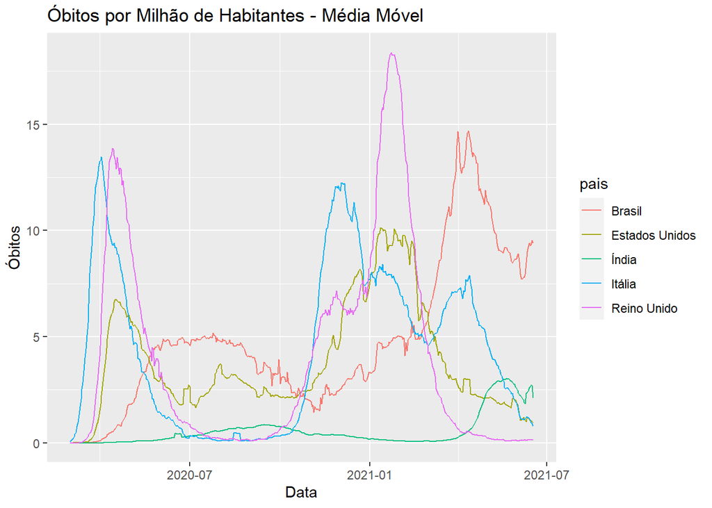

```r
df_master %>%
  filter(data >= "2020-03-01",
         pais == "Brasil" | pais == "Índia" | pais == "Estados Unidos" | pais == "Reino Unido" | pais == "Itália"
         ) %>%
  ggplot(aes(data, obitos_MM7d_1MH, colour = pais)) +
  geom_line() +
  xlab("Data") + ylab("Óbitos") +
  labs(title = "Óbitos por Milhão de Habitantes - Média Móvel")
```

### 5.2.2 Ásia

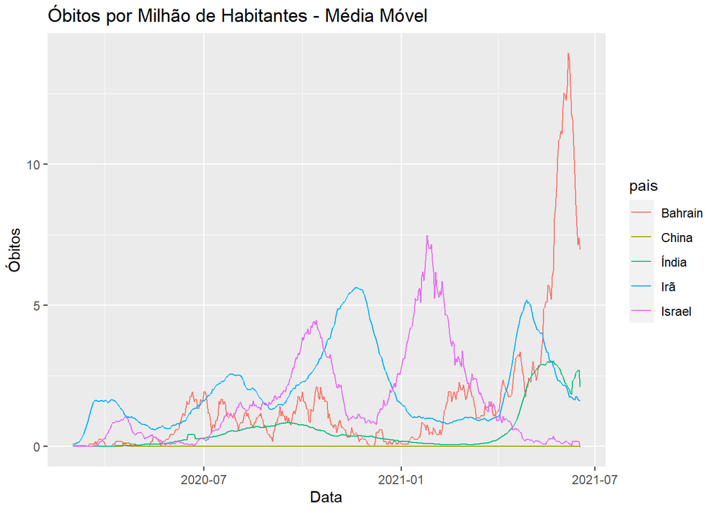

```r
df_master %>%
  filter(data >= "2020-03-01",
         pais == "Índia" | pais == "China" | pais == "Irã" | pais == "Bahrain" | pais == "Israel"
         ) %>%
  ggplot(aes(data, obitos_MM7d_1MH, colour = pais)) +
  geom_line() +
  xlab("Data") + ylab("Óbitos") +
  labs(title = "Óbitos por Milhão de Habitantes - Média Móvel")
```

### 5.2.3 Europa

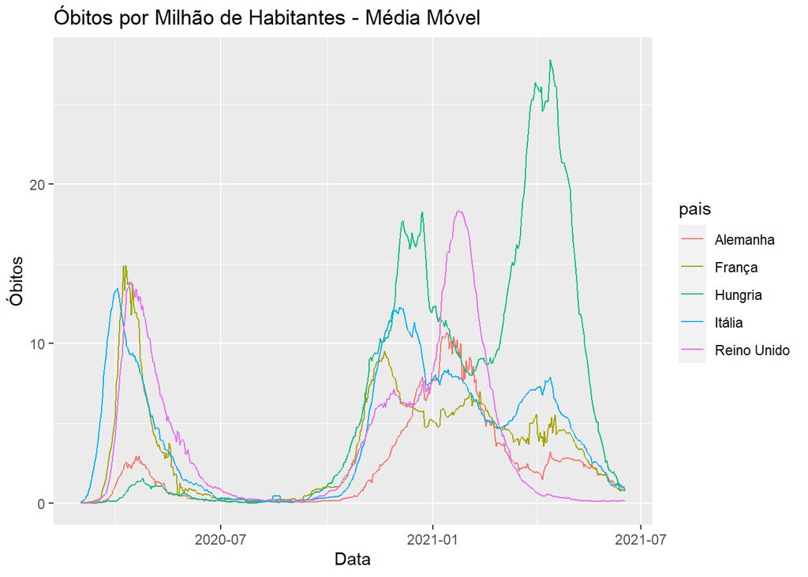

```r
df_master %>%
  filter(data >= "2020-03-01",
         pais == "Alemanha" | pais == "Reino Unido" | pais == "Itália" | pais == "França" | pais == "Hungria"
         ) %>%
  ggplot(aes(data, obitos_MM7d_1MH, colour = pais)) +
  geom_line() +
  xlab("Data") + ylab("Óbitos") +
  labs(title = "Óbitos por Milhão de Habitantes - Média Móvel")
```

### 5.2.4 América Central/Norte

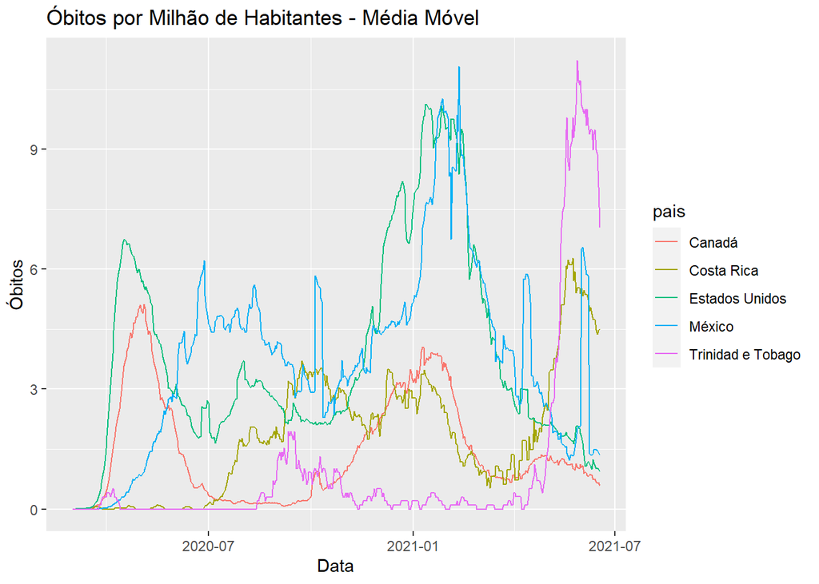

```r
df_master %>%
  filter(data >= "2020-03-01",
         pais == "Estados Unidos" | pais == "Canadá" | pais == "México" | pais == "Costa Rica" | pais == "Trinidad e Tobago"
         ) %>%
  ggplot(aes(data, obitos_MM7d_1MH, colour = pais)) +
  geom_line() +
  xlab("Data") + ylab("Óbitos") +
  labs(title = "Óbitos por Milhão de Habitantes - Média Móvel")
```

### 5.2.5 América do Sul

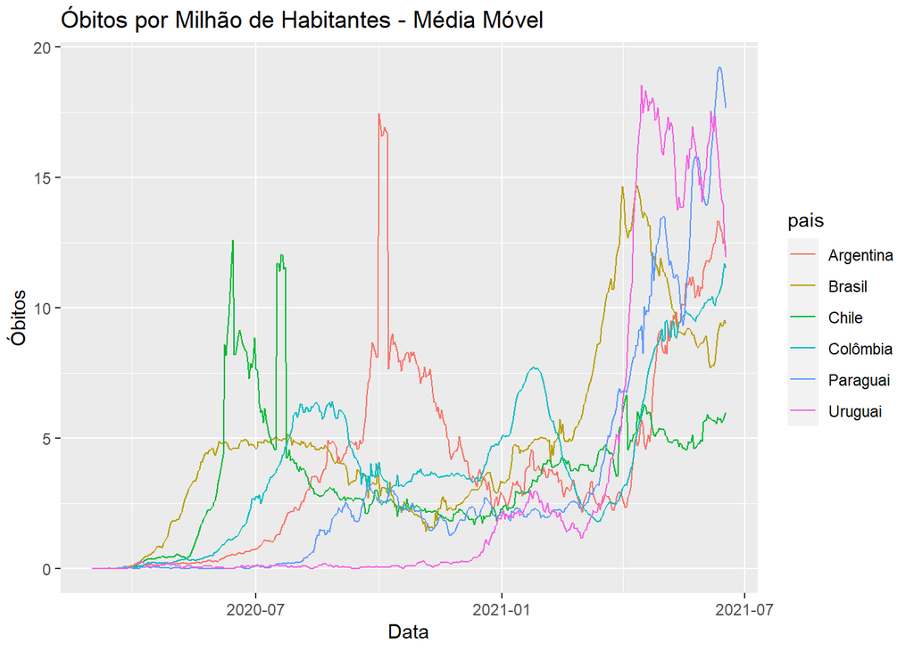

```r
df_master %>%
  filter(data >= "2020-03-01",
         pais == "Brasil" | pais == "Argentina" | pais == "Paraguai" | pais == "Colômbia" | pais == "Uruguai" |  pais == "Chile"
         ) %>%
  ggplot(aes(data, obitos_MM7d_1MH, colour = pais)) +
  geom_line() +
  xlab("Data") + ylab("Óbitos") +
  labs(title = "Óbitos por Milhão de Habitantes - Média Móvel")
```

### 5.2.6 África

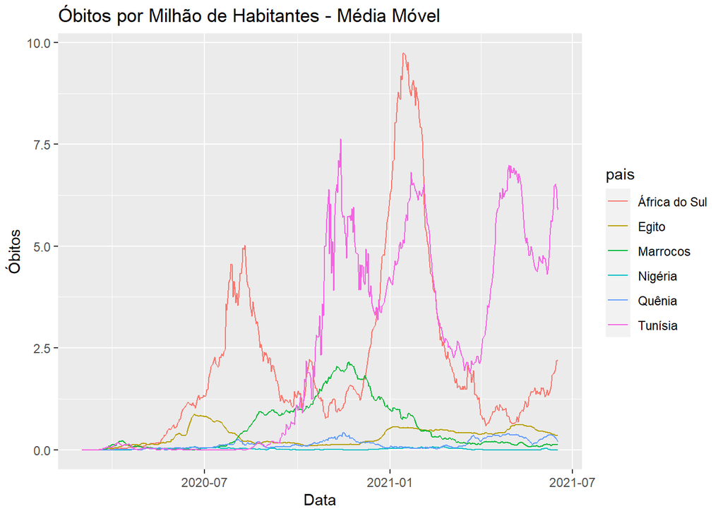

```r
df_master %>%
  filter(data >= "2020-03-01",
         pais == "África do Sul" | pais == "Egito" | pais == "Marrocos" | pais == "Nigéria" | pais == "Quênia" |  pais == "Tunísia"
         ) %>%
  ggplot(aes(data, obitos_MM7d_1MH, colour = pais)) +
  geom_line() +
  xlab("Data") + ylab("Óbitos") +
  labs(title = "Óbitos por Milhão de Habitantes - Média Móvel")
```

## 5.3 Evolução dos casos por Covid-19

Análise da evolução do número de casos por milhão de habitantes ao longo do tempo.

### 5.3.1 Global

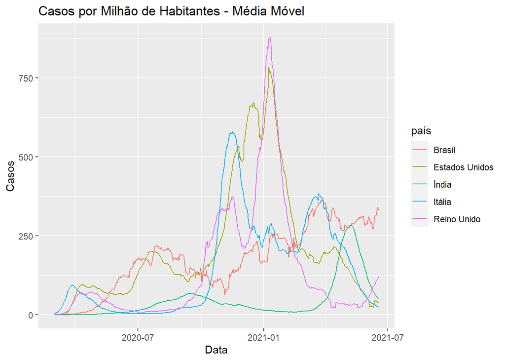

```r
df_master %>%
  filter(data >= "2020-03-01",
         pais == "Brasil" | pais == "Índia" | pais == "Estados Unidos" | pais == "Reino Unido" | pais == "Itália"
         ) %>%
  ggplot(aes(data, casos_MM7d_1MH, colour = pais)) +
  geom_line() +
  xlab("Data") + ylab("Casos") +
  labs(title = "Casos por Milhão de Habitantes - Média Móvel")
```

### 5.3.2 Ásia

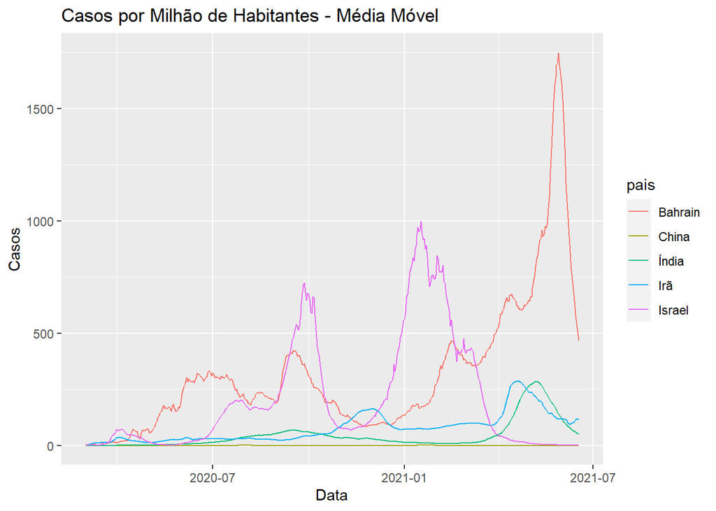

```r
df_master %>%
  filter(data >= "2020-03-01",
         pais == "Índia" | pais == "China" | pais == "Irã" | pais == "Bahrain" | pais == "Israel"
         ) %>%
  ggplot(aes(data, casos_MM7d_1MH, colour = pais)) +
  geom_line() +
  xlab("Data") + ylab("Casos") +
  labs(title = "Casos por Milhão de Habitantes - Média Móvel")
```

### 5.3.3 Europa

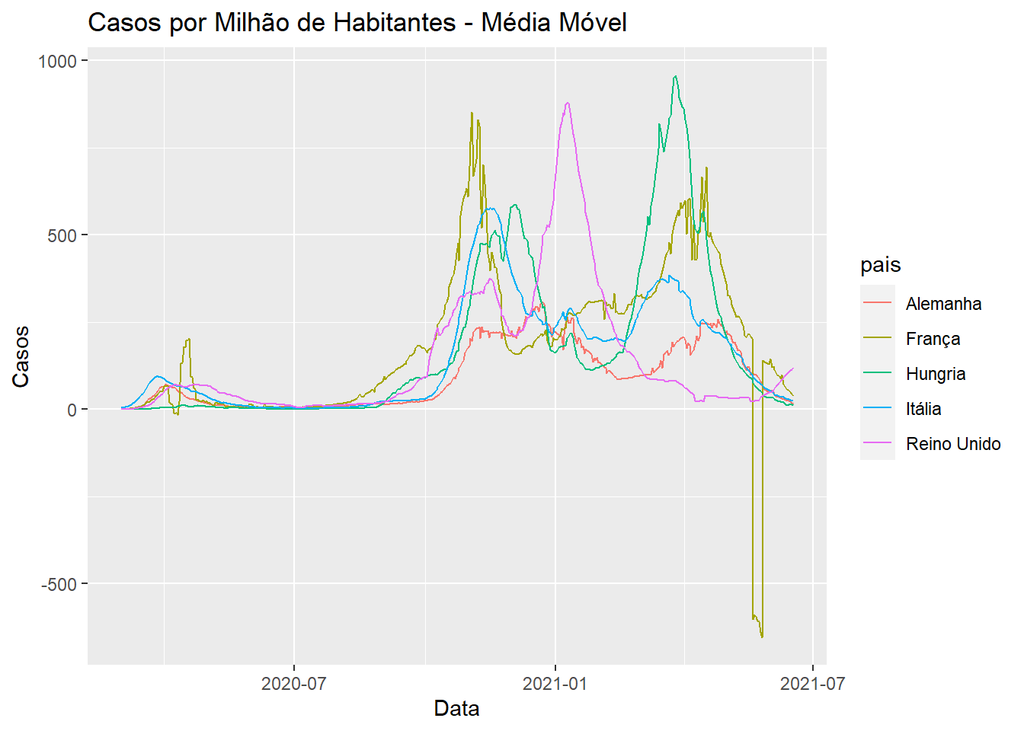

```r
df_master %>%
  filter(data >= "2020-03-01",
         pais == "Alemanha" | pais == "Reino Unido" | pais == "Itália" | pais == "França" | pais == "Hungria"
         ) %>%
  ggplot(aes(data, casos_MM7d_1MH, colour = pais)) +
  geom_line() +
  xlab("Data") + ylab("Casos") +
  labs(title = "Casos por Milhão de Habitantes - Média Móvel")
```

### 5.3.4 América Central/Norte

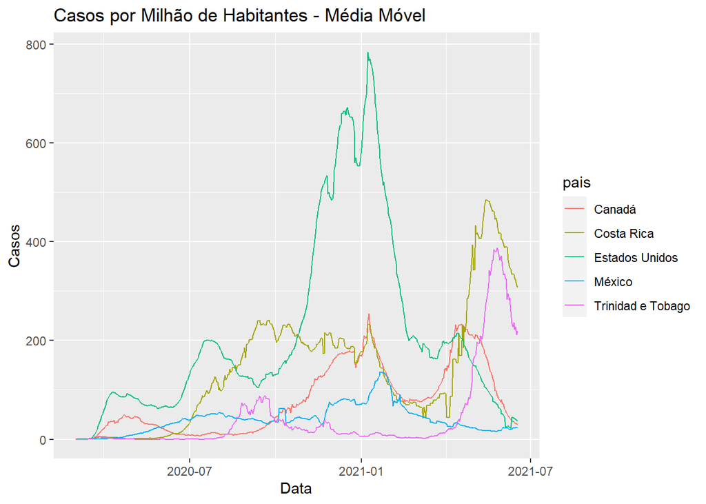

```r
df_master %>%
  filter(data >= "2020-03-01",
         pais == "Estados Unidos" | pais == "Canadá" | pais == "México" | pais == "Costa Rica" | pais == "Trinidad e Tobago"
         ) %>%
  ggplot(aes(data, casos_MM7d_1MH, colour = pais)) +
  geom_line() +
  xlab("Data") + ylab("Casos") +
  labs(title = "Casos por Milhão de Habitantes - Média Móvel")
```

### 5.3.5 América do Sul

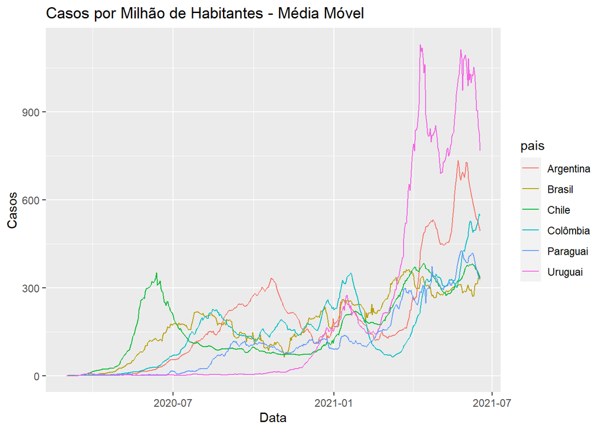

```r
df_master %>%
  filter(data >= "2020-03-01",
         pais == "Brasil" | pais == "Argentina" | pais == "Paraguai" | pais == "Colômbia" | pais == "Uruguai" |  pais == "Chile"
         ) %>%
  ggplot(aes(data, casos_MM7d_1MH, colour = pais)) +
  geom_line() +
  xlab("Data") + ylab("Casos") +
  labs(title = "Casos por Milhão de Habitantes - Média Móvel")
```

### 5.3.6 África

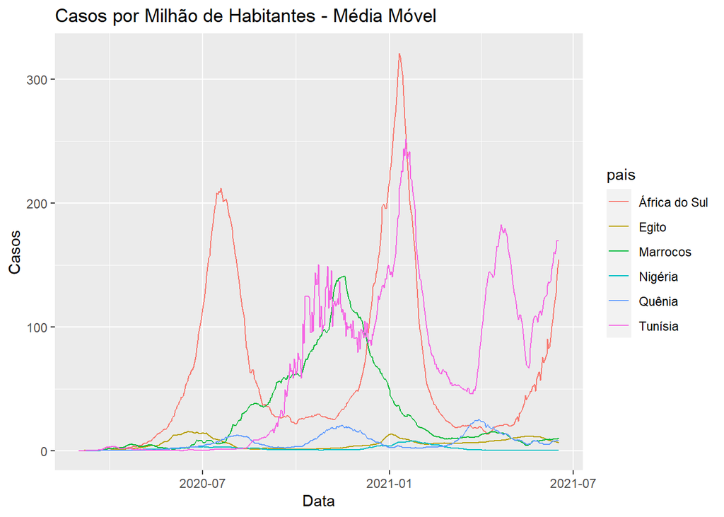

```r
df_master %>%
  filter(data >= "2020-03-01",
         pais == "África do Sul" | pais == "Egito" | pais == "Marrocos" | pais == "Nigéria" | pais == "Quênia" |  pais == "Tunísia"
         ) %>%
  ggplot(aes(data, casos_MM7d_1MH, colour = pais)) +
  geom_line() +
  xlab("Data") + ylab("Casos") +
  labs(title = "Casos por Milhão de Habitantes - Média Móvel")
```